# R Programming (Code Supplement)

### Add One More Function to Plot Data

You’re doing great! We should add one more function to the package. This function, `CompareOnStats()`, should take a data table of season stats and create a scatterplot showing pairs of statistics for each player. For example, you could use this function to answer the question *Did Marquette’s highest scorers also tend to be beter rebounders?*.

You’re a pro at adding new functions now, so I won’t belabor the points about adding documentation, updating the DESCRIPTION file, etc.. Let’s jump straight into an implementation of the funciton:

**RquetteBB/R/my_functions.R**

```r
#' @title Scatterplot Comparison of Player Stats
#' @name CompareOnStats
#' @description Given a data.table of Marquette men's basketball statistics, plot a bivariate
#'              scatterplot of player performance on the basis of two statistics
#' @import data.table
#' @importFrom graphics plot text
#' @param statDT A data.table of Marquette season stats, pulled with \code{\link[RquetteBB]{GetData}}
#' @param x_stat A string with the name of the statistic to plot on the x-axis
#' @param y_stat A string with the name of the statistic to plot on the y-axis
#' @param season String indicating which season you pull data for. Used to create plot title
#' @param useInitials A boolean. If TRUE, player initials will be plotted. If FALSE, full names will be used.
#' @export
CompareOnStats <- function(statDT
                           , x_stat = "PTS"
                           , y_stat = "TRB"
                           , season
                           , useInitials = TRUE
){

    # Create a scatterplot
    plot(
        x = statDT[, get(x_stat)]
        , y = statDT[, get(y_stat)]
        , xlab = x_stat
        , ylab = y_stat
        , type = "p"
        , col = "white"
        , main = paste0(x_stat, " vs. ", y_stat, " (", season, ")")
    )

    # Grab abbreviations from player names if asked
    if (useInitials){
        namesToPlot <- NamesToAbbreviations(statDT[, Player])
    } else {
        namesToPlot <- statDT[, Player]
    }

    # Add those abbreviations to the plot
    text(
        x = statDT[, get(x_stat)]
        , y = statDT[, get(y_stat)]
        , labels = namesToPlot
    )

    return(invisible(NULL))
}
```

### Final Step: Use Our Package to Do Stuff!

Congratulations on reaching the end of this tutorial. You’ve now created your first R package! We can use it to do some cool stuff.

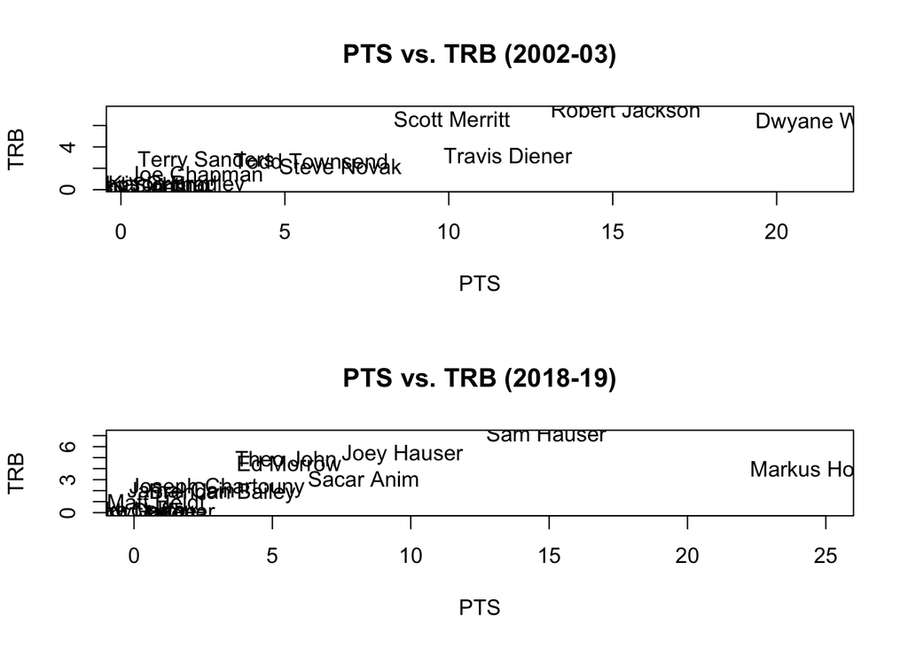

```r
# Load up our package
library(RquetteBB)

# Plot 2 on top of each other
par(mfrow = c(2, 1))

# Plot the 2002-2003 data
statsDT <- GetData(season = "2003")
CompareOnStats(
    statDT = statsDT
    , "PTS"
    , "TRB"
    , season = "2002-03"
    , useInitials = FALSE
)

# Plot the 2018-2019 data
statsDT <- GetData(season = "2019")
CompareOnStats(
    statDT = statsDT
    , "PTS"
    , "TRB"
    , season = "2018-19"
    , useInitials = FALSE
)
```

```r
# Reset graphical settings
par(mfrow = c(1, 1))
```

### Additional Resources

- **writing packages**: [Hillary Parker tutorial](https://hilaryparker.com/2014/04/29/writing-an-r-package-from-scratch/) | [Hadley’s R Packages book](http://r-pkgs.had.co.nz/)
- **unit testing**: [Getting Started with testthat](https://journal.r-project.org/archive/2011-1/RJournal_2011-1_Wickham.pdf) | [testthat repo](https://github.com/hadley/testthat) | [testthat docs](https://cran.r-project.org/web/packages/testthat/index.html)